# decision_trees

# “Random” Bagged Forests

#### Specify model and view

```r
rand_bag1 <- randomForest(HighIncome ~ Insurance + ElectricBill + HouseCosts + NumBedrooms , data=acs_test, mtry=4,
                          importance = TRUE, na.action = na.omit)
rand_bag1
```

```
##
## Call:
##  randomForest(formula = HighIncome ~ Insurance + ElectricBill +      HouseCosts + NumBedrooms, data = acs_test, mtry = 4, importance = TRUE,      na.action = na.omit)
##                Type of random forest: regression
##                      Number of trees: 500
## No. of variables tried at each split: 4
##
##           Mean of squared residuals: 0.05200682
##                     % Var explained: 7.49
```

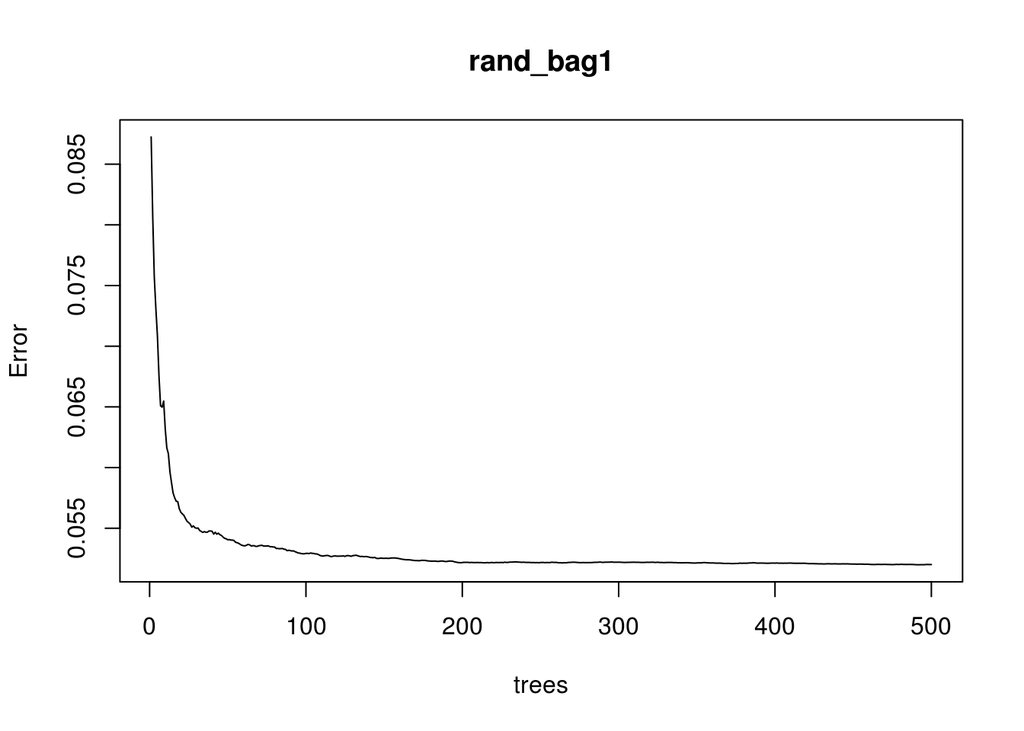

```r
# plot model
plot(rand_bag1)
```

#### Paper or plastic? Time to bag using fit data

1. Predict using model on fit data set
2. Display tail of predictions for visual inspection
3. Transform prediction probability to binary 1 or 0 based on criteria prob > .5
4. Create confusion matrix
5. Display confusion matrix
6. Residual analysis

```r
bag1_fit <- predict(rand_bag1, acs_fit, type="class" )

tail(bag1_fit)
```

```
##         22739         22740         22741         22742         22743
##  2.756667e-02  6.306667e-02  1.466667e-02  2.439333e-01 -8.783252e-17
##         22744
## -8.908152e-17
```

```r
acs_fit$HighIncome_bag <- ifelse(bag1_fit > .5,1,0)

bag_cm1_fit <- confusionMatrix(acs_fit$HighIncome_bag, acs_fit$HighIncome, positive = "1")

bag_cm1_fit
```

```
## Confusion Matrix and Statistics
##
##           Reference
## Prediction     0     1
##          0 16875   935
##          1   204   182
##
##                Accuracy : 0.9374
##                  95% CI : (0.9338, 0.9409)
##     No Information Rate : 0.9386
##     P-Value [Acc > NIR] : 0.7572
##
##                   Kappa : 0.2175
##  Mcnemar's Test P-Value : <2e-16
##
##             Sensitivity : 0.16294
##             Specificity : 0.98806
##          Pos Pred Value : 0.47150
##          Neg Pred Value : 0.94750
##              Prevalence : 0.06139
##          Detection Rate : 0.01000
##    Detection Prevalence : 0.02121
##       Balanced Accuracy : 0.57550
##
##        'Positive' Class : 1
##
```

```r
# Residual analysis
summary(acs_test$HighIncome - predict(rand_bag1,newdata=acs_fit))
```

```
##     Min.  1st Qu.   Median     Mean  3rd Qu.     Max.
## -0.96420 -0.06583 -0.00680 -0.00872  0.00000  1.00000
```

#### Predict using model on test data

1. Make predictions
2. Transform prediction probability to binary 1 or 0 based on criteria prob > .5
3. Create confusion matrix
4. Display confusion matrix
5. Residual analysis

```r
bag1_pred <- predict(rand_bag1, acs_test, type="class" )

acs_test$HighIncome_bag <- ifelse(bag1_pred > .5,1,0)

bag_cm1_pred <- confusionMatrix(acs_test$HighIncome_bag, acs_test$HighIncome, positive = "1")

bag_cm1_pred
```

```
## Confusion Matrix and Statistics
##
##           Reference
## Prediction    0    1
##          0 4277   94
##          1    0  178
##
##                Accuracy : 0.9793
##                  95% CI : (0.9748, 0.9833)
##     No Information Rate : 0.9402
##     P-Value [Acc > NIR] : < 2.2e-16
##
##                   Kappa : 0.7807
##  Mcnemar's Test P-Value : < 2.2e-16
##
##             Sensitivity : 0.65441
##             Specificity : 1.00000
##          Pos Pred Value : 1.00000
##          Neg Pred Value : 0.97849
##              Prevalence : 0.05979
##          Detection Rate : 0.03913
##    Detection Prevalence : 0.03913
##       Balanced Accuracy : 0.82721
##
##        'Positive' Class : 1
##
```

```r
# Residual analysis
summary(acs_test$HighIncome - predict(rand_bag1,newdata=acs_test))
```

```
##      Min.   1st Qu.    Median      Mean   3rd Qu.      Max.
## -0.487400 -0.027430 -0.002400 -0.003223  0.000000  0.793500
```